# Supervised Learning - Foundations Project: ReCell

## Problem Statement

### Business Context

Buying and selling used phones and tablets used to be something that happened on a handful of online marketplace sites. But the used and refurbished device market has grown considerably over the past decade, and a new IDC (International Data Corporation) forecast predicts that the used phone market would be worth \$52.7bn by 2023 with a compound annual growth rate (CAGR) of 13.6% from 2018 to 2023. This growth can be attributed to an uptick in demand for used phones and tablets that offer considerable savings compared with new models.

Refurbished and used devices continue to provide cost-effective alternatives to both consumers and businesses that are looking to save money when purchasing one. There are plenty of other benefits associated with the used device market. Used and refurbished devices can be sold with warranties and can also be insured with proof of purchase. Third-party vendors/platforms, such as Verizon, Amazon, etc., provide attractive offers to customers for refurbished devices. Maximizing the longevity of devices through second-hand trade also reduces their environmental impact and helps in recycling and reducing waste. The impact of the COVID-19 outbreak may further boost this segment as consumers cut back on discretionary spending and buy phones and tablets only for immediate needs.

### Objective

The rising potential of this comparatively under-the-radar market fuels the need for an ML-based solution to develop a dynamic pricing strategy for used and refurbished devices. ReCell, a startup aiming to tap the potential in this market, has hired you as a data scientist. They want you to analyze the data provided and build a linear regression model to predict the price of a used phone/tablet and identify factors that significantly influence it.

### Data Description

The data contains the different attributes of used/refurbished phones and tablets. The data was collected in the year 2021. The detailed data dictionary is given below.

- brand_name: Name of manufacturing brand
- os: OS on which the device runs
- screen_size: Size of the screen in cm
- 4g: Whether 4G is available or not
- 5g: Whether 5G is available or not
- main_camera_mp: Resolution of the rear camera in megapixels
- selfie_camera_mp: Resolution of the front camera in megapixels
- int_memory: Amount of internal memory (ROM) in GB
- ram: Amount of RAM in GB
- battery: Energy capacity of the device battery in mAh
- weight: Weight of the device in grams
- release_year: Year when the device model was released
- days_used: Number of days the used/refurbished device has been used
- normalized_new_price: Normalized price of a new device of the same model in euros
- normalized_used_price: Normalized price of the used/refurbished device in euros

## Importing necessary libraries

```python
# Installing the libraries with the specified version.
# uncomment and run the following line if Google Colab is being used
!pip install scikit-learn==1.2.2 seaborn==0.13.1 matplotlib==3.7.1 numpy==1.25.2 pandas==1.5.3 -q --user
```

```python
# Installing the libraries with the specified version.
# uncomment and run the following lines if Jupyter Notebook is being used
# !pip install scikit-learn==1.2.2 seaborn==0.11.1 matplotlib==3.3.4 numpy==1.24.3 pandas==1.5.2 -q --user
```

**Note**: *After running the above cell, kindly restart the notebook kernel and run all cells sequentially from the start again.*

## Problem definition and Questions to be answered:

ReCell is a startup in the used and refurbished device market. It seeks to develop an ML-based pricing model to predict device prices and identify key factors influencing them. This model will help ReCell set competitive, data-driven prices and optimize their strategy in a growing market.

**Key Objectives**

- Price Prediction: Build a linear regression model to predict the price of used phones/tablets based on features.
- Influential Factors: Identify which device features (e.g., brand, age, condition) most affect price.
- Market Insights: Analyze trends, segment pricing, and compare with competitor prices.
- COVID-19 Impact: Assess any price shifts due to pandemic-related demand changes.

```python
# Libraries to help with reading and manipulating data
import pandas as pd
import numpy as np

# Libraries used with data visualization
import matplotlib.pyplot as plt
import seaborn as sns

# Spliting the data into Train and Test sets
from sklearn.model_selection import train_test_split

import statsmodels.api as sm

# To build linear regression model
from sklearn.linear_model import LinearRegression

# Model performance measurement
from sklearn.metrics import mean_squared_error, r2_score, mean_absolute_error

# To calculate VIF
from statsmodels.stats.outliers_influence import variance_inflation_factor

import warnings
warnings.simplefilter(action='ignore', category=FutureWarning)
```

```python
# Load the data
data = pd.read_csv('/content/used_device_data.csv')
```

## Data Overview

The initial steps to get an overview of any dataset is to:

- observe the first few rows of the dataset, to check whether the dataset has been loaded properly or not
- get information about the number of rows and columns in the dataset
- find out the data types of the columns to ensure that data is stored in the preferred format and the value of each property is as expected.
- check the statistical summary of the dataset to get an overview of the numerical columns of the data

### Displaying the first few rows of the dataset

```python
# Viewing the first 5 rows of data
data.head()
```

|  | brand_name | os | screen_size | 4g | 5g | main_camera_mp | selfie_camera_mp | int_memory | ram | battery | weight | release_year | days_used | normalized_used_price | normalized_new_price |
| --- | --- | --- | --- | --- | --- | --- | --- | --- | --- | --- | --- | --- | --- | --- | --- |
| 0 | Honor | Android | 14.50 | yes | no | 13.0 | 5.0 | 64.0 | 3.0 | 3020.0 | 146.0 | 2020 | 127 | 4.307572 | 4.715100 |
| 1 | Honor | Android | 17.30 | yes | yes | 13.0 | 16.0 | 128.0 | 8.0 | 4300.0 | 213.0 | 2020 | 325 | 5.162097 | 5.519018 |
| 2 | Honor | Android | 16.69 | yes | yes | 13.0 | 8.0 | 128.0 | 8.0 | 4200.0 | 213.0 | 2020 | 162 | 5.111084 | 5.884631 |
| 3 | Honor | Android | 25.50 | yes | yes | 13.0 | 8.0 | 64.0 | 6.0 | 7250.0 | 480.0 | 2020 | 345 | 5.135387 | 5.630961 |
| 4 | Honor | Android | 15.32 | yes | no | 13.0 | 8.0 | 64.0 | 3.0 | 5000.0 | 185.0 | 2020 | 293 | 4.389995 | 4.947837 |

```python
# Viewing the last 5 rows of data
data.tail()
```

|  | brand_name | os | screen_size | 4g | 5g | main_camera_mp | selfie_camera_mp | int_memory | ram | battery | weight | release_year | days_used | normalized_used_price | normalized_new_price |
| --- | --- | --- | --- | --- | --- | --- | --- | --- | --- | --- | --- | --- | --- | --- | --- |
| 3449 | Asus | Android | 15.34 | yes | no | NaN | 8.0 | 64.0 | 6.0 | 5000.0 | 190.0 | 2019 | 232 | 4.492337 | 6.483872 |
| 3450 | Asus | Android | 15.24 | yes | no | 13.0 | 8.0 | 128.0 | 8.0 | 4000.0 | 200.0 | 2018 | 541 | 5.037732 | 6.251538 |
| 3451 | Alcatel | Android | 15.80 | yes | no | 13.0 | 5.0 | 32.0 | 3.0 | 4000.0 | 165.0 | 2020 | 201 | 4.357350 | 4.528829 |
| 3452 | Alcatel | Android | 15.80 | yes | no | 13.0 | 5.0 | 32.0 | 2.0 | 4000.0 | 160.0 | 2020 | 149 | 4.349762 | 4.624188 |
| 3453 | Alcatel | Android | 12.83 | yes | no | 13.0 | 5.0 | 16.0 | 2.0 | 4000.0 | 168.0 | 2020 | 176 | 4.132122 | 4.279994 |

```python
# Check the shape of the data
data.shape
```

```
(3454, 15)
```

The dataset contains 3454 rows and 15 columns

```python
# check the datatypes of the columns
data.info()
```

```
<class 'pandas.core.frame.DataFrame'>
RangeIndex: 3454 entries, 0 to 3453
Data columns (total 15 columns):
 #   Column                 Non-Null Count  Dtype
---  ------                 --------------  -----
 0   brand_name             3454 non-null   object
 1   os                     3454 non-null   object
 2   screen_size            3454 non-null   float64
 3   4g                     3454 non-null   object
 4   5g                     3454 non-null   object
 5   main_camera_mp         3275 non-null   float64
 6   selfie_camera_mp       3452 non-null   float64
 7   int_memory             3450 non-null   float64
 8   ram                    3450 non-null   float64
 9   battery                3448 non-null   float64
 10  weight                 3447 non-null   float64
 11  release_year           3454 non-null   int64
 12  days_used              3454 non-null   int64
 13  normalized_used_price  3454 non-null   float64
 14  normalized_new_price   3454 non-null   float64
dtypes: float64(9), int64(2), object(4)
memory usage: 404.9+ KB
```

**Observation:**

- The release_year and days_used columns are of int64 data type.
- There are four object type columns(brand_name, os, 4g, 5g), and the rest are all of type float.
- From the non-null count, we can see that some columns have missing values as their total count does not match the total number of rows in the data frame.

```python
# Statistical summary of the numerical data
data.describe().T
```

|  | count | mean | std | min | 25% | 50% | 75% | max |
| --- | --- | --- | --- | --- | --- | --- | --- | --- |
| screen_size | 3454.0 | 13.713115 | 3.805280 | 5.080000 | 12.700000 | 12.830000 | 15.340000 | 30.710000 |
| main_camera_mp | 3275.0 | 9.460208 | 4.815461 | 0.080000 | 5.000000 | 8.000000 | 13.000000 | 48.000000 |
| selfie_camera_mp | 3452.0 | 6.554229 | 6.970372 | 0.000000 | 2.000000 | 5.000000 | 8.000000 | 32.000000 |
| int_memory | 3450.0 | 54.573099 | 84.972371 | 0.010000 | 16.000000 | 32.000000 | 64.000000 | 1024.000000 |
| ram | 3450.0 | 4.036122 | 1.365105 | 0.020000 | 4.000000 | 4.000000 | 4.000000 | 12.000000 |
| battery | 3448.0 | 3133.402697 | 1299.682844 | 500.000000 | 2100.000000 | 3000.000000 | 4000.000000 | 9720.000000 |
| weight | 3447.0 | 182.751871 | 88.413228 | 69.000000 | 142.000000 | 160.000000 | 185.000000 | 855.000000 |
| release_year | 3454.0 | 2015.965258 | 2.298455 | 2013.000000 | 2014.000000 | 2015.500000 | 2018.000000 | 2020.000000 |
| days_used | 3454.0 | 674.869716 | 248.580166 | 91.000000 | 533.500000 | 690.500000 | 868.750000 | 1094.000000 |
| normalized_used_price | 3454.0 | 4.364712 | 0.588914 | 1.536867 | 4.033931 | 4.405133 | 4.755700 | 6.619433 |
| normalized_new_price | 3454.0 | 5.233107 | 0.683637 | 2.901422 | 4.790342 | 5.245892 | 5.673718 | 7.847841 |

```python
data.describe(include = ['object']).T
```

|  | count | unique | top | freq |
| --- | --- | --- | --- | --- |
| brand_name | 3454 | 34 | Others | 502 |
| os | 3454 | 4 | Android | 3214 |
| 4g | 3454 | 2 | yes | 2335 |
| 5g | 3454 | 2 | no | 3302 |

- The normalized used price varies between 1.54 and 6.62 dollars with an average of 4.36 dollars
- The normalized new price varies between 2.90 and 7.85 dollars with an average of 5.23 dollars
- Android is the most occurring type of os.
- The RAM of the devices varies from 0.02 GB to 12 GB with an average of 4.04 GB
- The weight of devices varies from 69g to 855g with an average of 182.75g
- The energy capacity of devices varies from 500 mAh to 9720 mAh with an average of 3133.40 mAh

```python
# Checking for missing values
data.isnull().sum()
```

|  | 0 |
| --- | --- |
| brand_name | 0 |
| os | 0 |
| screen_size | 0 |
| 4g | 0 |
| 5g | 0 |
| main_camera_mp | 179 |
| selfie_camera_mp | 2 |
| int_memory | 4 |
| ram | 4 |
| battery | 6 |
| weight | 7 |
| release_year | 0 |
| days_used | 0 |
| normalized_used_price | 0 |
| normalized_new_price | 0 |

**dtype:** int64

```python
# Checking for duplicated values
data.duplicated().sum()
```

```
0
```

## Exploratory Data Analysis (EDA)

- EDA is an important part of any project involving data.
- It is important to investigate and understand the data better before building a model with it.
- A few questions have been mentioned below which will help you approach the analysis in the right manner and generate insights from the data.
- A thorough analysis of the data, in addition to the questions mentioned below, should be done.

**Questions**: (Answered below with Bivariate Analysis)

1. What does the distribution of normalized used device prices look like?
2. What percentage of the used device market is dominated by Android devices?
3. The amount of RAM is important for the smooth functioning of a device. How does the amount of RAM vary with the brand?
4. A large battery often increases a device's weight, making it feel uncomfortable in the hands. How does the weight vary for phones and tablets offering large batteries (more than 4500 mAh)?
5. Bigger screens are desirable for entertainment purposes as they offer a better viewing experience. How many phones and tablets are available across different brands with a screen size larger than 6 inches?
6. A lot of devices nowadays offer great selfie cameras, allowing us to capture our favorite moments with loved ones. What is the distribution of devices offering greater than 8MP selfie cameras across brands?
7. Which attributes are highly correlated with the normalized price of a used device?

```python
# Function to plot a boxplot and histogram along the same scale

def histogram_boxplot(data, feature, figsize=(15, 10), kde=False, bins=None):
    """
    Boxplot and histogram combined

    data: dataframe
    feature: dataframe column
    figsize: size of figure (default (15,10))
    kde: whether to show the density curve (default False)
    bins: number of bins for histogram (default None)
    """
    f2, (ax_box2, ax_hist2) = plt.subplots(
        nrows=2,  # Number of rows of the subplot grid= 2
        sharex=True,  # x-axis will be shared among all subplots
        gridspec_kw={"height_ratios": (0.25, 0.75)},
        figsize=figsize,
    )  # creating the 2 subplots
    sns.boxplot(
        data=data, x=feature, ax=ax_box2, showmeans=True, color="violet"
    )  # boxplot will be created and a triangle will indicate the mean value of the column
    sns.histplot(
        data=data, x=feature, kde=kde, ax=ax_hist2, bins=bins
    ) if bins else sns.histplot(
        data=data, x=feature, kde=kde, ax=ax_hist2
    )  # For histogram
    ax_hist2.axvline(
        data[feature].mean(), color="green", linestyle="--"
    )  # Add mean to the histogram
    ax_hist2.axvline(
        data[feature].median(), color="black", linestyle="-"
    )  # Add median to the histogram
```

```python
# function to create labeled barplots

def labeled_barplot(data, feature, perc=False, n=None):
    """
    Barplot with percentages at the top
    data: dataframe
    feature: dataframe column
    perc: whether to display percentages instead of count (default is False)
    n: displays the top n category levels (default is None, i.e., display all levels)
    """

    total = len(data[feature])  # length of the column
    count = data[feature].nunique()
    if n is None:
        plt.figure(figsize=(count + 2, 6))
    else:
        plt.figure(figsize=(n + 2, 6))

    plt.xticks(rotation=90, fontsize=15)
    ax = sns.countplot(
        data=data,
        x=feature,
        hue=feature,
        palette="Paired",
        order=data[feature].value_counts().index[:n],
    )

    for p in ax.patches:
        if perc == True:
            label = "{:.1f}%".format(
                100 * p.get_height() / total
            )  # percentage of each class of the category
        else:
            label = p.get_height()  # count of each level of the category

        x = p.get_x() + p.get_width() / 2  # width of the plot
        y = p.get_height()  # height of the plot

        ax.annotate(
            label,
            (x, y),
            ha="center",
            va="center",
            size=12,
            xytext=(0, 5),
            textcoords="offset points",
        )  # annotate the percentage

    plt.show()  # show the plot
```

### UNIVARIATE ANALYSIS

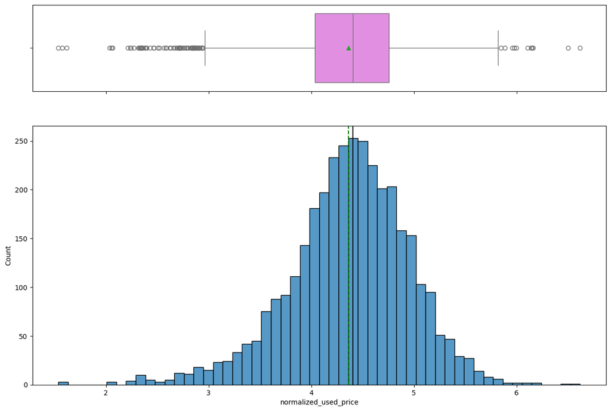

```python
# normalized_used_price
histogram_boxplot(data,"normalized_used_price")
```

```python
data["normalized_used_price"].describe()
```

|  | normalized_used_price |
| --- | --- |
| count | 3454.000000 |
| mean | 4.364712 |
| std | 0.588914 |
| min | 1.536867 |
| 25% | 4.033931 |
| 50% | 4.405133 |
| 75% | 4.755700 |
| max | 6.619433 |

**dtype:** float64

- The distribution of the normalized_used_price looks to be normal
- The boxplot shows outliers on both ends
- The average(mean) normalized_used_price is $4.36

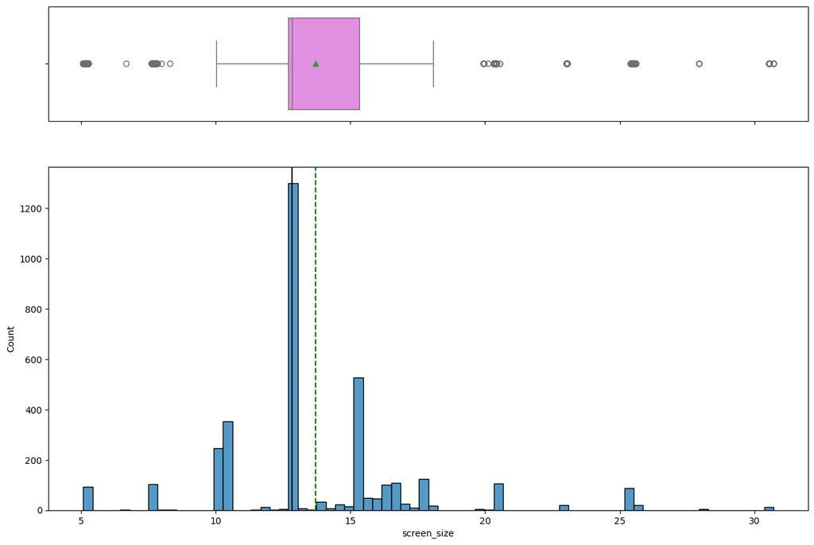

```python
# screen_size

histogram_boxplot(data,"screen_size")
```

```python
data["screen_size"].describe()
```

|  | screen_size |
| --- | --- |
| count | 3454.000000 |
| mean | 13.713115 |
| std | 3.805280 |
| min | 5.080000 |
| 25% | 12.700000 |
| 50% | 12.830000 |
| 75% | 15.340000 |
| max | 30.710000 |

**dtype:** float64

- Screen-size is right skewed
- Outliers to the right indicate very large screens
- Mean screen size is around 13.7 cm

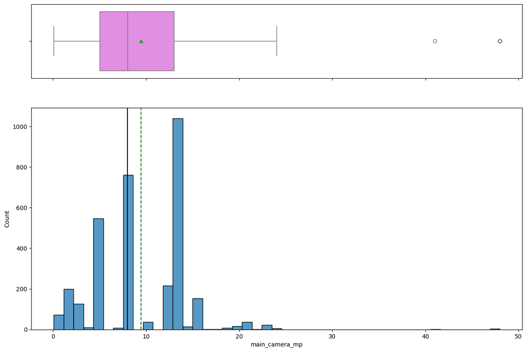

```python
# main_camera_mp
histogram_boxplot(data,"main_camera_mp")
```

```python
data["main_camera_mp"].describe()
```

|  | main_camera_mp |
| --- | --- |
| count | 3275.000000 |
| mean | 9.460208 |
| std | 4.815461 |
| min | 0.080000 |
| 25% | 5.000000 |
| 50% | 8.000000 |
| 75% | 13.000000 |
| max | 48.000000 |

**dtype:** float64

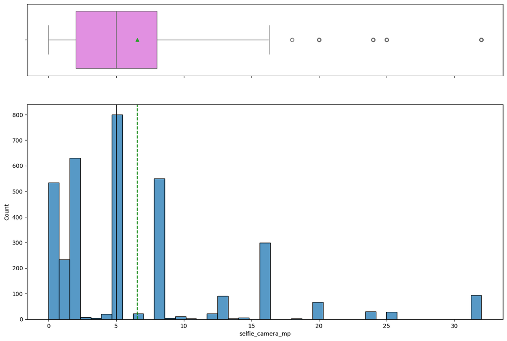

```python
# selfie_camera_mp
histogram_boxplot(data,"selfie_camera_mp")
```

```python
data["selfie_camera_mp"].describe()
```

|  | selfie_camera_mp |
| --- | --- |
| count | 3452.000000 |
| mean | 6.554229 |
| std | 6.970372 |
| min | 0.000000 |
| 25% | 2.000000 |
| 50% | 5.000000 |
| 75% | 8.000000 |
| max | 32.000000 |

**dtype:** float64

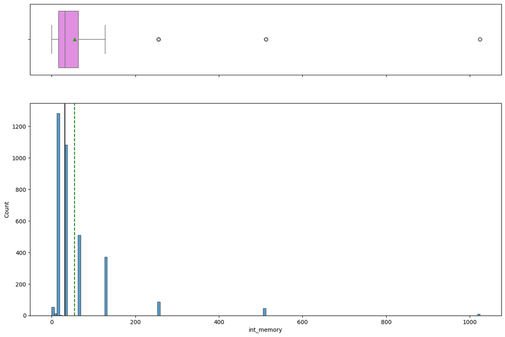

```python
# int_memory
histogram_boxplot(data,"int_memory")
```

```python
data["int_memory"].describe()
```

|  | int_memory |
| --- | --- |
| count | 3450.000000 |
| mean | 54.573099 |
| std | 84.972371 |
| min | 0.010000 |
| 25% | 16.000000 |
| 50% | 32.000000 |
| 75% | 64.000000 |
| max | 1024.000000 |

**dtype:** float64

- The distribution of the amount of internal memory for the devices is right skewed.
- There are outliers on the upper end.
- The average amount of internal memory for the devices is 54.57 GB.

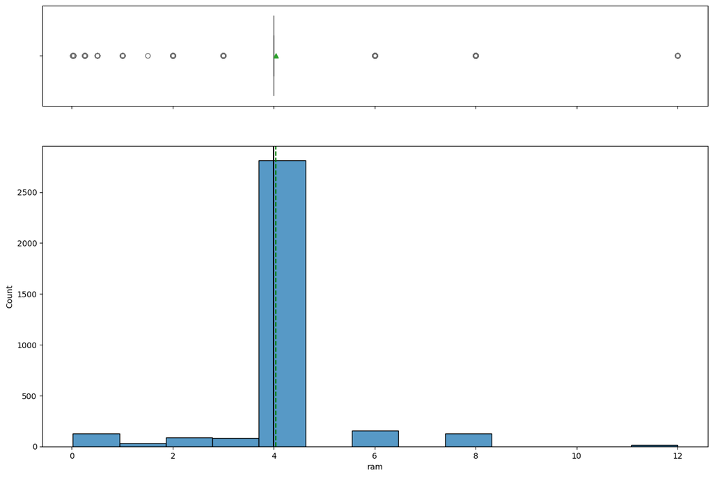

```python
# ram
histogram_boxplot(data,"ram")
```

```python
data["ram"].describe()
```

|  | ram |
| --- | --- |
| count | 3450.000000 |
| mean | 4.036122 |
| std | 1.365105 |
| min | 0.020000 |
| 25% | 4.000000 |
| 50% | 4.000000 |
| 75% | 4.000000 |
| max | 12.000000 |

**dtype:** float64

- The average amount of RAM for the devices is 4.04 GB.

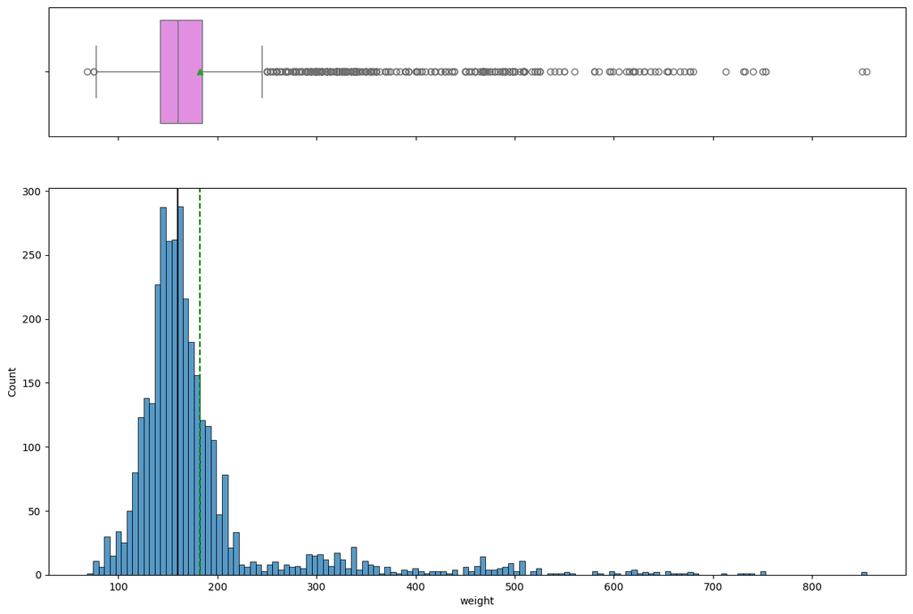

```python
# weight
histogram_boxplot(data,"weight")
```

```python
data["weight"].describe()
```

|  | weight |
| --- | --- |
| count | 3447.000000 |
| mean | 182.751871 |
| std | 88.413228 |
| min | 69.000000 |
| 25% | 142.000000 |
| 50% | 160.000000 |
| 75% | 185.000000 |
| max | 855.000000 |

**dtype:** float64

- The distribution of the weight appears to be right skewed
- There seems to be outliers on both the ends many on the right side indicating heavy phones
- The average weight for the devices is 182.75g

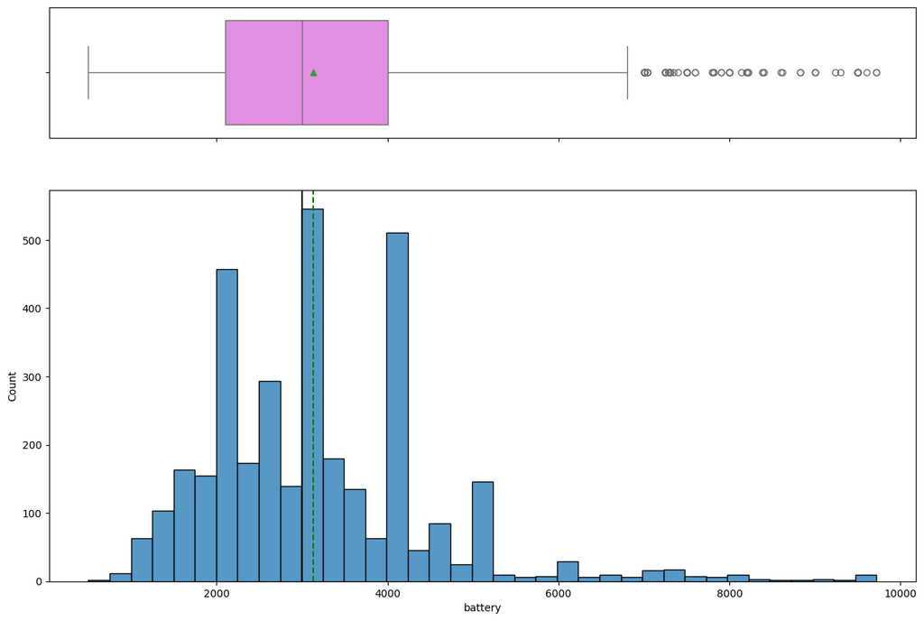

```python
# battery
histogram_boxplot(data,"battery")
```

```python
data["battery"].describe()
```

|  | battery |
| --- | --- |
| count | 3448.000000 |
| mean | 3133.402697 |
| std | 1299.682844 |
| min | 500.000000 |
| 25% | 2100.000000 |
| 50% | 3000.000000 |
| 75% | 4000.000000 |
| max | 9720.000000 |

**dtype:** float64

- The distribution of the battery capacity for the devices appears to be slightly right skewed
- There seems to be outliers on the upper end indicating phones with high capacity batteries
- The average energy capacity for the devices is 3133.4 mAh

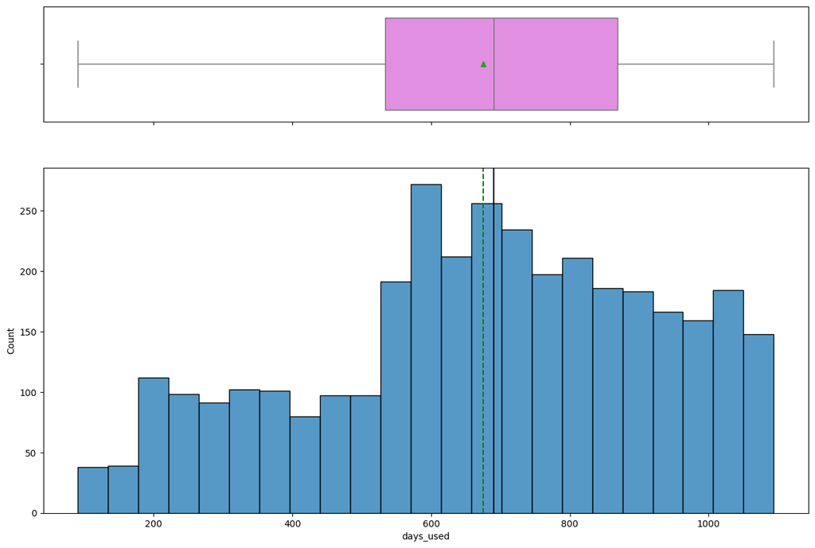

```python
# days_used
histogram_boxplot(data,"days_used")
```

```python
data["days_used"].describe()
```

|  | days_used |
| --- | --- |
| count | 3454.000000 |
| mean | 674.869716 |
| std | 248.580166 |
| min | 91.000000 |
| 25% | 533.500000 |
| 50% | 690.500000 |
| 75% | 868.750000 |
| max | 1094.000000 |

**dtype:** float64

- The distribution of the number of days a refurbished product is used appears to be skewed to the left.
- No outliers.
- The average number of days a refurbished product is used is about 675 days.

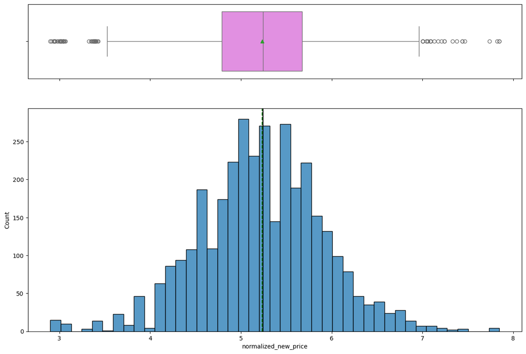

```python
# normalized_new_price

histogram_boxplot(data,"normalized_new_price")
```

```python
data["normalized_new_price"].describe()
```

|  | normalized_new_price |
| --- | --- |
| count | 3454.000000 |
| mean | 5.233107 |
| std | 0.683637 |
| min | 2.901422 |
| 25% | 4.790342 |
| 50% | 5.245892 |
| 75% | 5.673718 |
| max | 7.847841 |

**dtype:** float64

- The normalized_new-price seems to have a normal distribution
- Some outliers are present on both the ends
- The mean is 5.2

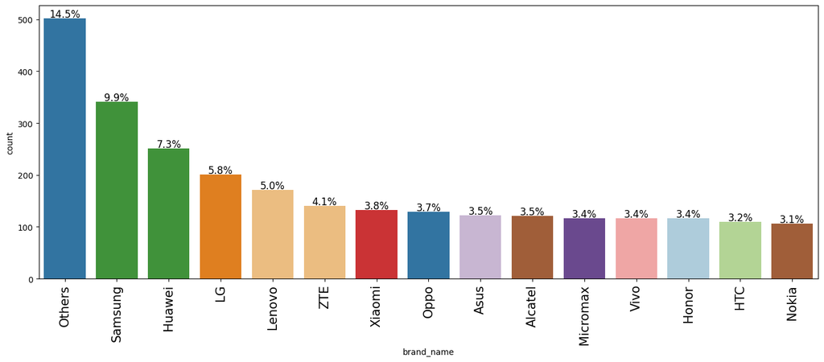

```python
# brand_name

labeled_barplot(data, "brand_name", perc=True, n=15)
```

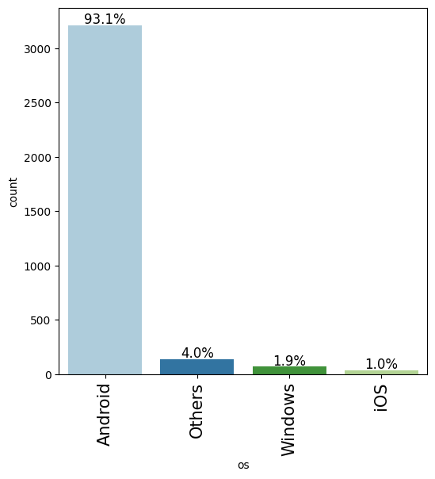

```python
labeled_barplot(data, "os", perc=True)
```

Android is the most popular operating system at 93% and ios being the least popular at 1%

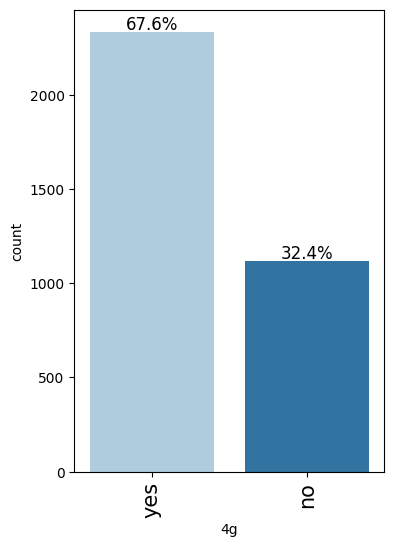

```python
labeled_barplot(data, "4g", perc=True)
```

Majority of the devices (67.6%) have 4g.

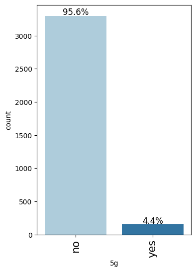

```python
labeled_barplot(data, "5g", perc=True)
```

Majority of the devices (95.6%) are not available with 5g.

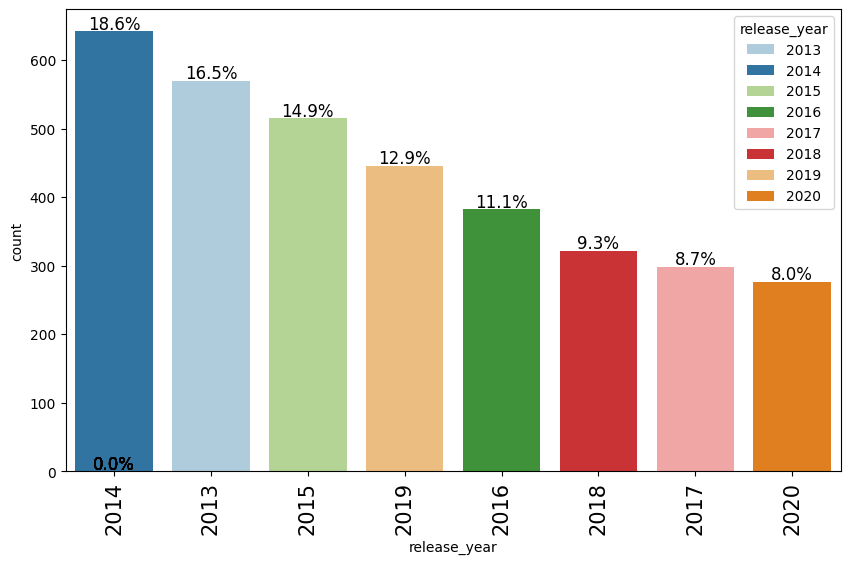

```python
# release_year
labeled_barplot(data, "release_year", perc=True)
```

Many of the devices (18.6%) were released in 2014. This is followed by 2013 and 2015 with 16.5% and 14.9%.

### Bivariate Analysis and answers to the questions mentioned in the problem statement

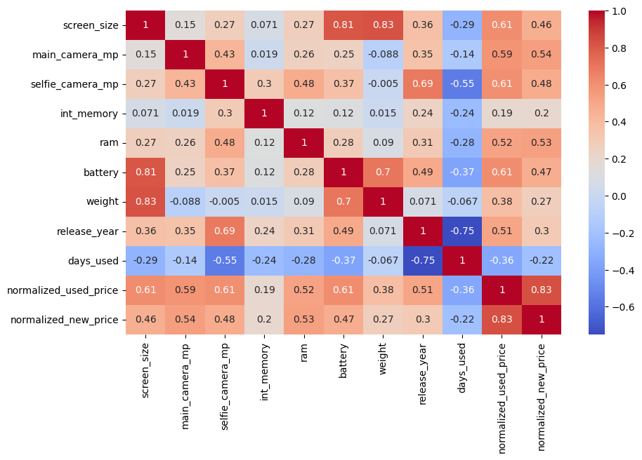

```python
# Correlation Check
cols_list = data.select_dtypes(include=np.number).columns.tolist()
corr = data[cols_list].corr()

cols_list.remove("release_year")

plt.figure(figsize=(10, 6))
sns.heatmap(corr, annot=True, cmap="coolwarm");
```

- The normalized used device price is highly correlated with the normalized price of a new device model. This makes sense as the price of a new model is likely to affect the used device price. The normalized used price of a device has an 0.83 correlation factor with the normalized price of a used device.
- The normalized used device price is also moderately correlated with the resolution of the cameras provided, the size of the screen, and the battery capacity.
- Weight, screen size, and battery capacity of a device show a good amount of correlation. This makes sense as larger battery capacity requires bigger space, thereby increasing screen size and weight.
- The number of days a device is used is negatively correlated with the resolution of its front camera. This makes sense as older devices did not offer as powerful front cameras as the recent ones.

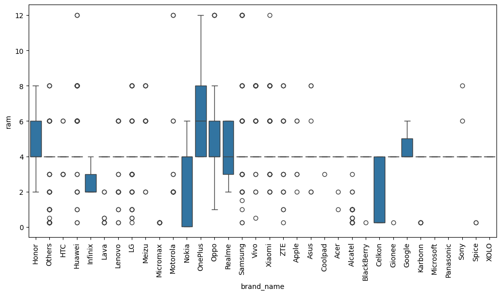

```python
# brand_name vs ram

plt.figure(figsize=(12, 6))
sns.boxplot(data, x='brand_name',y='ram' )
plt.xticks(rotation=90)
plt.show()
```

- 50% of the devices offered by most of the companies hve 4GB of RAM.
- 50% of OnePlus devices have 6GB or more RAM, indicating that OnePlus devices offer more RAM in general.
- OnePlus has the highest amount of RAM while Celkon has a below average amount of RAM.

### Questions

**1. What does the distribution of normalized used device prices look like?**

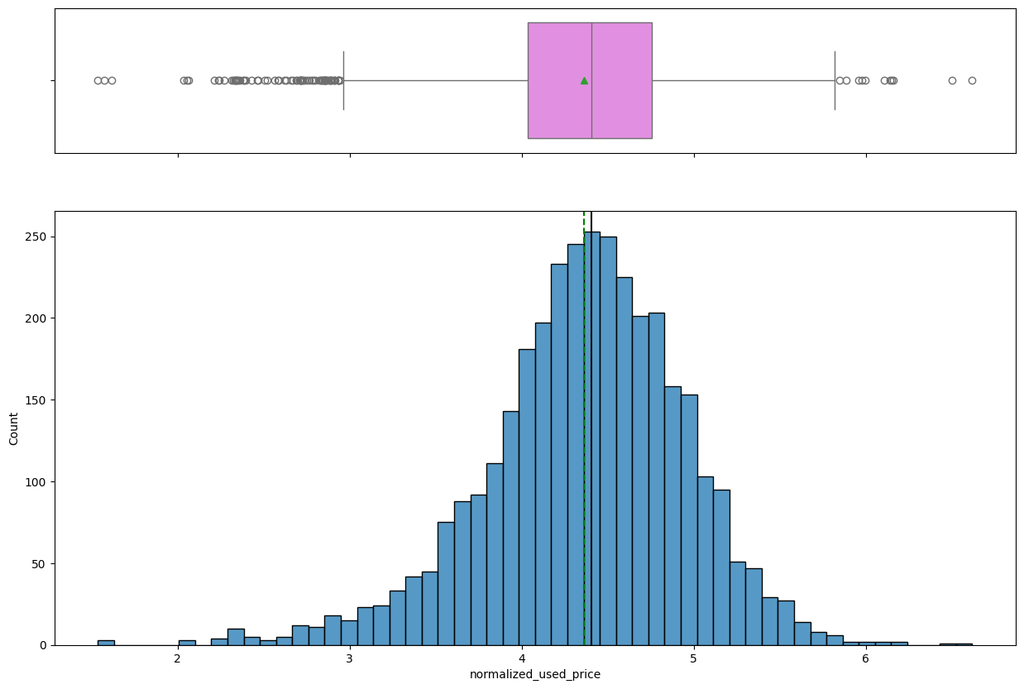

```python
histogram_boxplot(data,"normalized_used_price")
```

- The distribution of the normalized_used_price looks to be normal
- The boxplot shows outliers on both ends
- The average(mean) normalized_used_price is $4.36

**2. What percentage of the used device market is dominated by Android devices?**

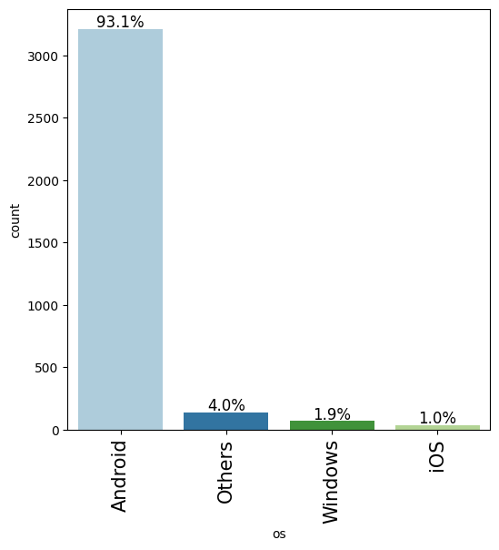

```python
labeled_barplot(data, "os", perc=True)
```

The Android devices dominate the market as they make up 93.1% of it. IOS has the smallest market share in the used phone market with 1.0%

**3. The amount of RAM is important for the smooth functioning of a device. How does the amount of RAM vary with the brand?**

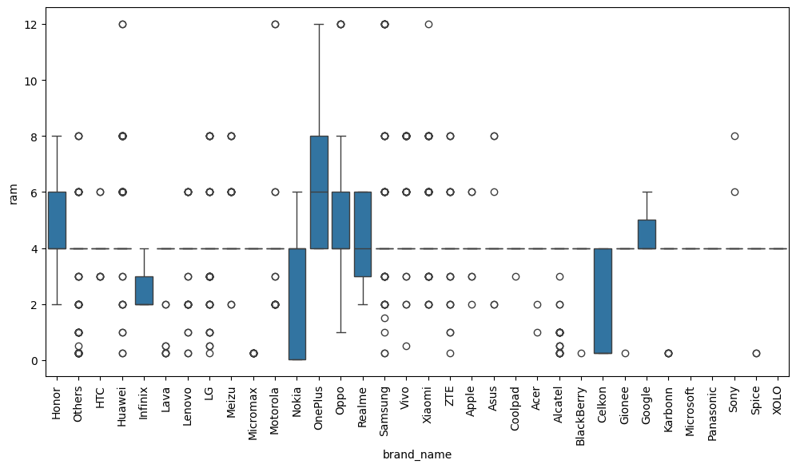

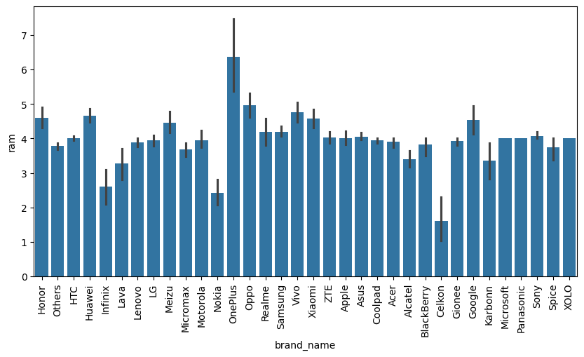

```python
plt.figure(figsize=(12, 6))
sns.boxplot(data, x='brand_name',y='ram' )
plt.xticks(rotation=90)
plt.show()

plt.figure(figsize=(10,5))
plt.xticks(rotation=90)
sns.barplot(data, x="brand_name", y="ram")
plt.show()
```

- The distribution of RAM for various brands seems to be different from one another
- Ther are outliers and not normally distributed
- The brand that has the most RAM is OnePlus and the brand that has the least RAM is Celkon.

**4. A large battery often increases a device's weight, making it feel uncomfortable in the hands. How does the weight vary for phones and tablets offering large batteries (more than 4500 mAh)?**

```python
# using only those rows of data wherein the battery power is more than 4500 mAh
large_battery_phones = data[(data['battery'] > 4500)]
large_battery_phones.shape
```

```
(341, 15)
```

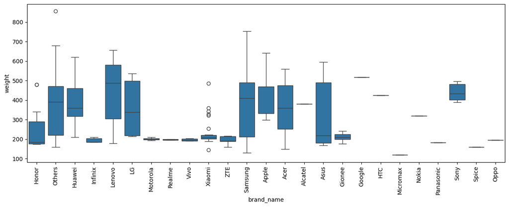

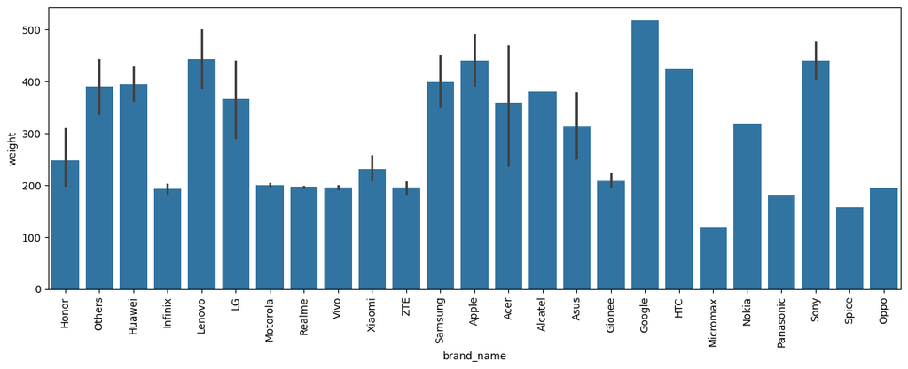

```python
plt.figure(figsize=(15, 5))
sns.boxplot(data=large_battery_phones, x="brand_name", y="weight")
plt.xticks(rotation=90)
plt.show()

plt.figure(figsize=(15, 5))
sns.barplot(data=large_battery_phones, x="brand_name", y="weight")
plt.xticks(rotation=90)
plt.show()
```

- The distribution of the weight of the devices associated with the brand seems to be different from one another
- None of the distributions appear to be normally distributed
- Some brand distributions for the weight have outliers.
- The heaviest devices belong to Google and the lightest devices to Micromax

**5. Bigger screens are desirable for entertainment purposes as they offer a better viewing experience. How many phones and tablets are available across different brands with a screen size larger than 6 inches?**

```python
# screen size is in cm, to convert it into inches multiply by 2.54

large_screen_phones = data[(data['screen_size'] > 6*2.54)]
large_screen_phones.shape
```

```
(1099, 15)
```

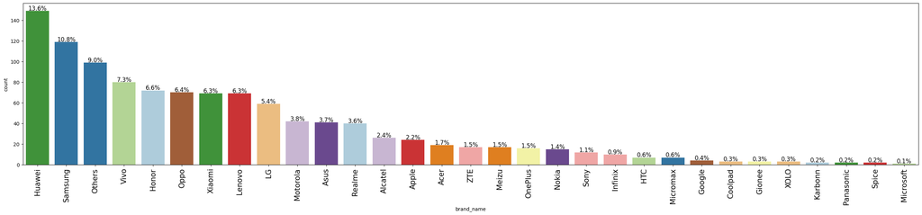

```python
labeled_barplot(large_screen_phones, "brand_name", perc=True)
```

Huawei offers the nighest number of phones with a screensize greater than 6 inches, taking up 13.6% of the market.

This is followed by Samsung and other miscellaneous brands with market shares of 10.8% and 9%, respectively.

**6. A lot of devices nowadays offer great selfie cameras, allowing us to capture our favorite moments with loved ones. What is the distribution of devices offering greater than 8MP selfie cameras across brands?**

```python
higher_pixel_phones = data[(data['selfie_camera_mp'] > 8)]
higher_pixel_phones.shape
```

```
(655, 15)
```

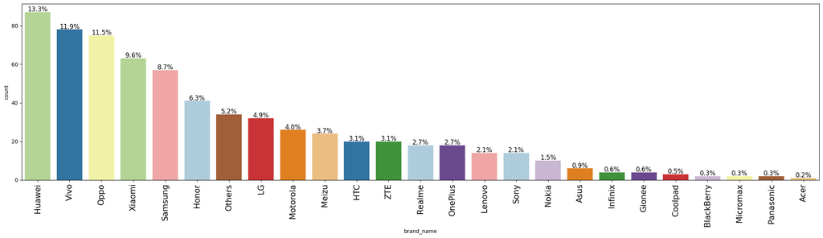

```python
labeled_barplot(higher_pixel_phones, "brand_name", perc=True)
```

The brand that has the most amount of devices with selfie cameras that have more than 8 MP is Huawei, taking up 13.3% of the market. This is followed by Vivo and Oppo with market shares of 11.9% and 11.5%.

**Analysis for rear cameras (resolution to be greater than 16MP) with respect to brand**

```python
main_camera=data[(data['main_camera_mp'] > 16)]
main_camera.shape
```

```
(94, 15)
```

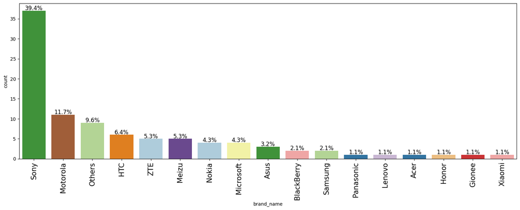

```python
labeled_barplot(main_camera, "brand_name", perc=True)
```

The brand that has the most amount of devices with main cameras that have more than 16 MP is Sony, taking up 39.4% of the market. This is followed by Motorola and other miscellaneous brands with market shares of 11.7% and 9.6%

**7. Which attributes are highly correlated with the normalized price of a used device?**

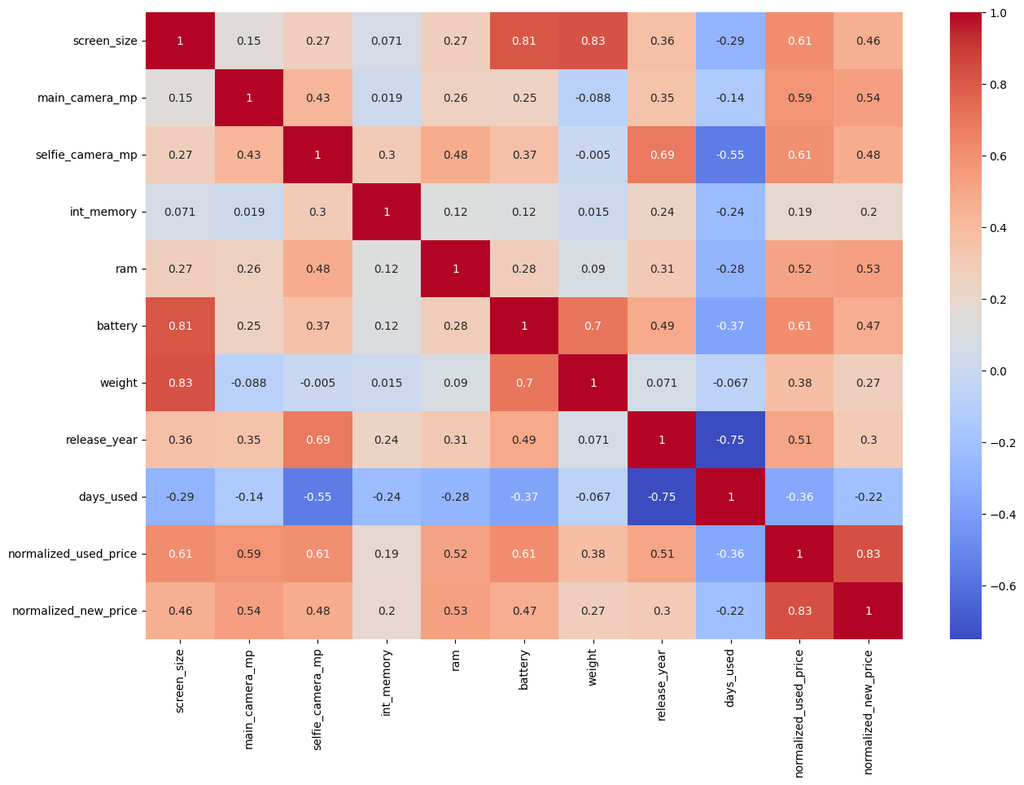

```python
numerical_data = data.select_dtypes(include=np.number)

plt.figure(figsize=(15, 10))
sns.heatmap(numerical_data.corr(), annot=True, cmap="coolwarm")
plt.show()
```

The normalized price of a used device is highly positively correlated with the following:

- normalized new price of the device, which means that as the new price of a phone increases, the used price of a phone also tends to increase.
- battery
- selfie camera
- screen size
- The normalized price of the devices is negatively correlated with the number of days the device has been used, which means as the number of days used increases the normalized price decreases.
- days_used is negatively correlated with release_year, which means that as the number of days a phone has been used increases, the year a phone was released tends to decrease.
- screen_size is positively correlated with battery and weight, which means that as a phone's screen size increases, the weight of the phone and the size of the battery also tend to increase.

**Analysis of the price of used devices varying across the years.**

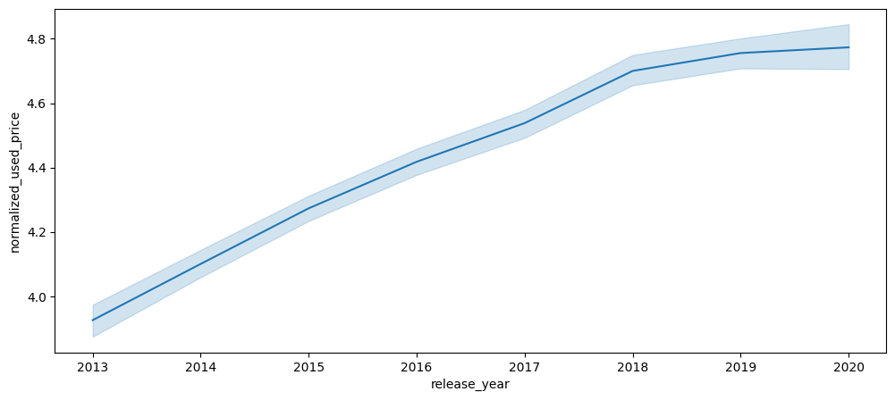

```python
plt.figure(figsize=(12, 5))
sns.lineplot(data, x='release_year', y='normalized_used_price')
plt.show()
```

There is a postive relationship between the release year of the device and the normalized used price. As the release year of the devices increases, the normalized used price increases as well.

**Analysis of the normalized new price of devices varying across the years.**

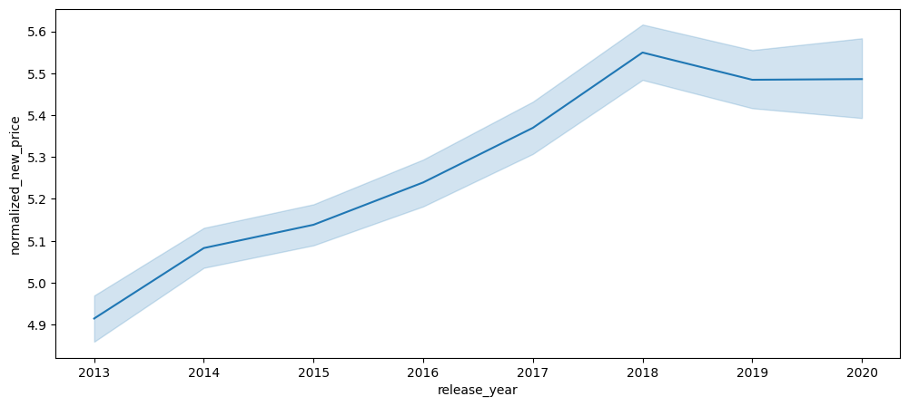

```python
plt.figure(figsize=(12, 5))
sns.lineplot(data, x='release_year', y='normalized_new_price')
plt.show()
```

The price of new phones has increased from 2013 to 2018, with prices falling slightly in 2019 and steadying out into 2020.

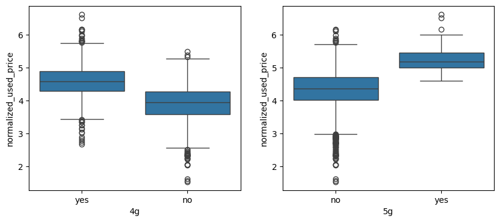

```python
# analysis of the price for used phones and tablets offering 4G and 5G networks.

plt.figure(figsize=(10, 4))

plt.subplot(121)
sns.boxplot(data, x="4g", y="normalized_used_price")

plt.subplot(122)
sns.boxplot(data, x="5g", y="normalized_used_price")

plt.show()
```

- The devices with 4g availbilty have a higher normalized price than devices that don't.
- It appears that devices with 5g availbilty have a higher normalized price than devices that don't.
- Devices that possess 5g have a higher normalized price than devices that possess 4g.

## Data Preprocessing

- Missing value treatment
- Feature engineering
- Outlier detection and treatment
- Preparing data for modeling

```python
# make a copy of the data
data_copy1 = data.copy()
```

```python
data_copy1.isnull().sum()
```

|  | 0 |
| --- | --- |
| brand_name | 0 |
| os | 0 |
| screen_size | 0 |
| 4g | 0 |
| 5g | 0 |
| main_camera_mp | 179 |
| selfie_camera_mp | 2 |
| int_memory | 4 |
| ram | 4 |
| battery | 6 |
| weight | 7 |
| release_year | 0 |
| days_used | 0 |
| normalized_used_price | 0 |
| normalized_new_price | 0 |

**dtype:** int64

There are 6 variables with missing data

- main_camera_mp has 179 missing values
- selfie_camera_mp has 2 missing values
- int_memory has 4 missing values
- ram has 4 missing values
- battery has 6 missing values
- weight has 7 missing values

```python
# creating a list of variables that contain missing values

cols_missingValues = [
    "main_camera_mp",
    "selfie_camera_mp",
    "int_memory",
    "ram",
    "battery",
    "weight",
]
```

```python
# imputing missing values in the list cols_missingValues with median by grouping the data on release year and brand name

for col in cols_missingValues:
  data_copy1[col]= data_copy1[col].fillna(data_copy1.groupby(['release_year','brand_name'])[col].transform('median'))

data_copy1.isnull().sum()
```

|  | 0 |
| --- | --- |
| brand_name | 0 |
| os | 0 |
| screen_size | 0 |
| 4g | 0 |
| 5g | 0 |
| main_camera_mp | 179 |
| selfie_camera_mp | 2 |
| int_memory | 0 |
| ram | 0 |
| battery | 6 |
| weight | 7 |
| release_year | 0 |
| days_used | 0 |
| normalized_used_price | 0 |
| normalized_new_price | 0 |

**dtype:** int64

```python
# Fill any remaining values in the cols_missingValues using a fallback median of the column

cols_missingValues = [
    "main_camera_mp",
    "selfie_camera_mp",
    "battery",
    "weight",
]
for col in cols_missingValues:
  data_copy1[col]=data_copy1[col].fillna(data_copy1.groupby(['brand_name'])[col].transform("median"))

data_copy1.isnull().sum()
```

|  | 0 |
| --- | --- |
| brand_name | 0 |
| os | 0 |
| screen_size | 0 |
| 4g | 0 |
| 5g | 0 |
| main_camera_mp | 10 |
| selfie_camera_mp | 0 |
| int_memory | 0 |
| ram | 0 |
| battery | 0 |
| weight | 0 |
| release_year | 0 |
| days_used | 0 |
| normalized_used_price | 0 |
| normalized_new_price | 0 |

**dtype:** int64

```python
# filling the remaining missing values in the main_camera_mp with the median of that column

data_copy1['main_camera_mp'] = data_copy1['main_camera_mp'].fillna(data_copy1['main_camera_mp'].median())

data_copy1.isnull().sum()
```

|  | 0 |
| --- | --- |
| brand_name | 0 |
| os | 0 |
| screen_size | 0 |
| 4g | 0 |
| 5g | 0 |
| main_camera_mp | 0 |
| selfie_camera_mp | 0 |
| int_memory | 0 |
| ram | 0 |
| battery | 0 |
| weight | 0 |
| release_year | 0 |
| days_used | 0 |
| normalized_used_price | 0 |
| normalized_new_price | 0 |

**dtype:** int64

All the missing values have been treated.

## Feature Engineering

- Convert the feature release_year to years_since_released
- Drop the release_year column

```python
# convert the release_year to the years_since_released

data_copy1['years_since_released'] = 2021 - data_copy1['release_year']
data_copy1['years_since_released'].describe()
```

|  | years_since_released |
| --- | --- |
| count | 3454.000000 |
| mean | 5.034742 |
| std | 2.298455 |
| min | 1.000000 |
| 25% | 3.000000 |
| 50% | 5.500000 |
| 75% | 7.000000 |
| max | 8.000000 |

**dtype:** float64

```python
# dropping the release_year column
data_copy1.drop(['release_year'], axis=1, inplace=True)
```

### Outlier Detection and Treatment

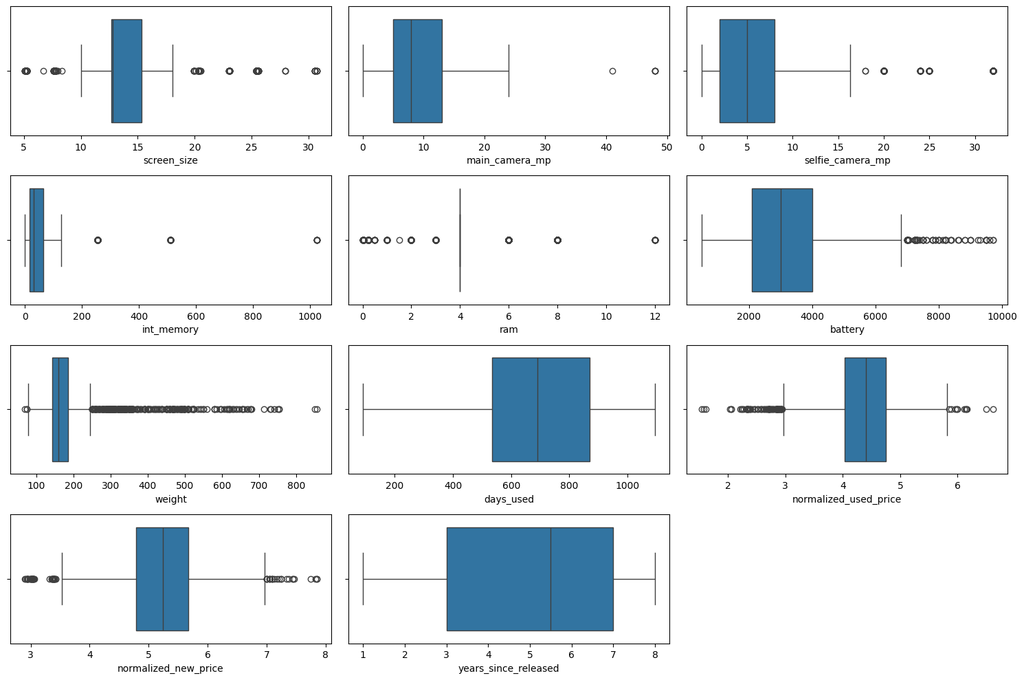

```python
# detect outliers using boxplots

numeric_cols = data_copy1.select_dtypes(include=np.number).columns.tolist()

plt.figure(figsize=(15, 10))

for i, variable in enumerate (numeric_cols):
  plt.subplot(4,3,i+1)
  sns.boxplot(data_copy1, x=variable)
  plt.tight_layout()

plt.show()
```

- There are outliers in the data
- Lets write flooring and capping functions to treat them

```python
# functions to treat outliers by flooring and capping

def treat_outliers(data_copy1, col):
    """
    Treats outliers in a variable

    df: dataframe
    col: dataframe column
    """
    Q1 = data_copy1[col].quantile(0.25)  # 25th quantile
    Q3 = data_copy1[col].quantile(0.75)  # 75th quantile
    IQR = Q3 - Q1
    Lower_Whisker = Q1 - 1.5 * IQR
    Upper_Whisker = Q3 + 1.5 * IQR

    # all the values smaller than Lower_Whisker will be assigned the value of Lower_Whisker
    # all the values greater than Upper_Whisker will be assigned the value of Upper_Whisker
    data_copy1[col] = np.clip(data_copy1[col], Lower_Whisker, Upper_Whisker)

    return data_copy1


def treat_outliers_all(data_copy1, col_list):
    """
    Treat outliers in a list of variables

    df: dataframe
    col_list: list of dataframe columns
    """
    for c in col_list:
        df = treat_outliers(data_copy1, c)

    return data_copy1
```

```python
# list of columns to treat for outliers
treat_out_cols = ["normalized_new_price", "battery",
                  "int_memory", "selfie_camera_mp", "main_camera_mp", "screen_size"]
```

We will not treat outliers in the ram column as doing so will remove the variation in the column and most likely make it a constant, which is not desirable, and so it is omitted in the list of columns to treat.

```python
# create a new data frame after treating outliers in the colums
data_copy1 = treat_outliers_all(data_copy1, treat_out_cols)
```

### Re-check columns to see if outliers were treated

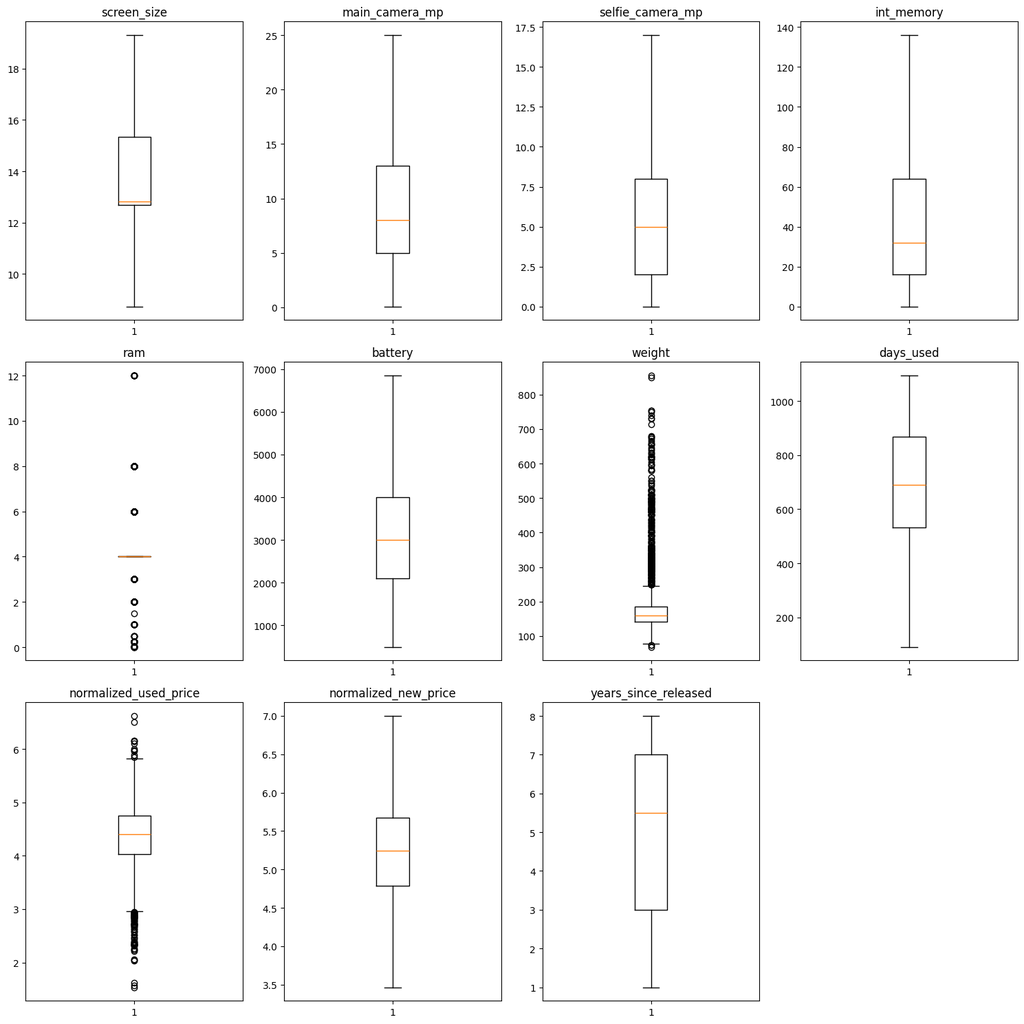

```python
# outlier detection using boxplot
numeric_columns = data_copy1.select_dtypes(include=np.number).columns.tolist()

plt.figure(figsize=(15, 15))

for i, variable in enumerate(numeric_columns):
    plt.subplot(3, 4, i + 1)
    plt.boxplot(data_copy1[variable], whis=1.5)
    plt.tight_layout()
    plt.title(variable)

plt.show()
```